# World Cup 2026 Forecast Retrospective

Point-in-time evidence for xGelo v2

# 1 Scorecard

The strict latest-valid benchmark covers **83 of 104 fixtures (79.8%)**. Its regulation-time ranked probability score is **0.1669**, with a deterministic 95% fixture bootstrap interval of **0.1504 to 0.1841**.

The paired latest-minus-first change is **-0.0018** (95% interval **-0.0049 to 0.0012**). Negative values favor the latest revision; this interval includes zero.

**Caveats.** Twenty-one fixtures have no strict eligible forecast. Historical JSON retains only the five leading scorelines, about 46.5% of joint probability mass, so complete joint and marginal goal-distribution scores are unavailable. No retained team-stage snapshot predates the opening kickoff; stage-reach results therefore use strictly pre-stage anchors only. Exploratory evidence is reported separately and never blended into the strict scorecard.

Strict latest-valid scorecard

|  | metric | n_scored | n_official | coverage | estimate | lower | upper |
| --- | --- | --- | --- | --- | --- | --- | --- |
| 412 | btts_brier | 83 | 104 | 0.7981 | 0.2495 | 0.2422 | 0.2569 |
| 457 | over_2_5_brier | 83 | 104 | 0.7981 | 0.2460 | 0.2399 | 0.2518 |
| 475 | accuracy | 83 | 104 | 0.7981 | 0.6988 | 0.5904 | 0.7952 |
| 484 | brier | 83 | 104 | 0.7981 | 0.4893 | 0.4331 | 0.5468 |
| 493 | log_loss | 83 | 104 | 0.7981 | 0.8500 | 0.7680 | 0.9344 |
| 502 | rps | 83 | 104 | 0.7981 | 0.1669 | 0.1504 | 0.1841 |

# 2 Provenance And Coverage

Every forecast occurrence is tied to its Git commit, archived forecast blob, dashboard blob, feature-table blob, home and away model blobs, generation time, committer time, and declared source cutoffs. Strict records require all three times to be before kickoff with no grace period.

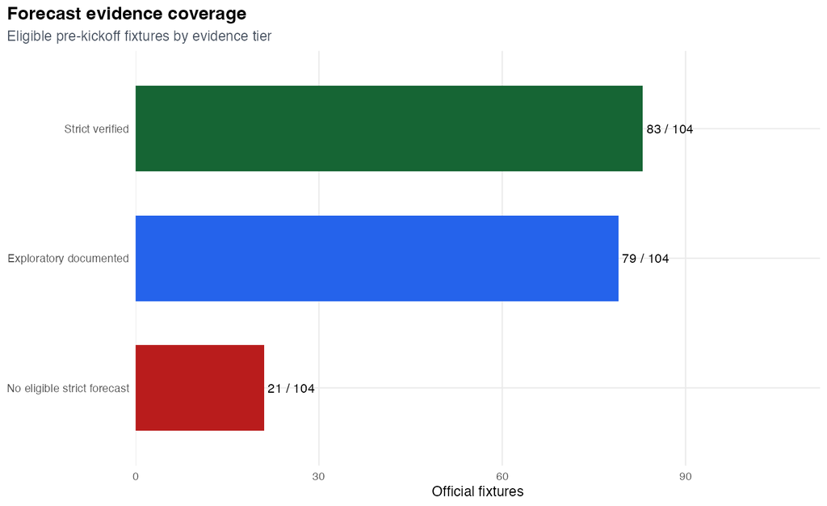

Committed forecast occurrences by evidence tier

| evidence_tier | occurrences |
| --- | --- |
| documented | 339 |
| rejected | 29930 |
| verified | 6401 |

# 3 Match Outcomes

RPS is the primary 1X2 metric. Multiclass Brier score and log loss are supporting proper scores; accuracy is descriptive. Every headline aggregate weights fixtures equally.

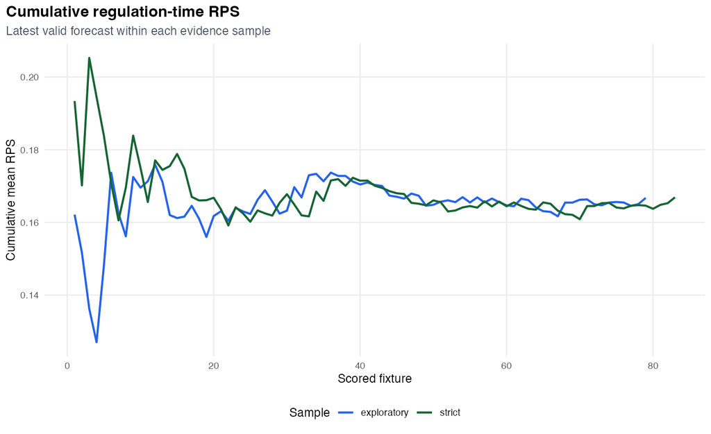

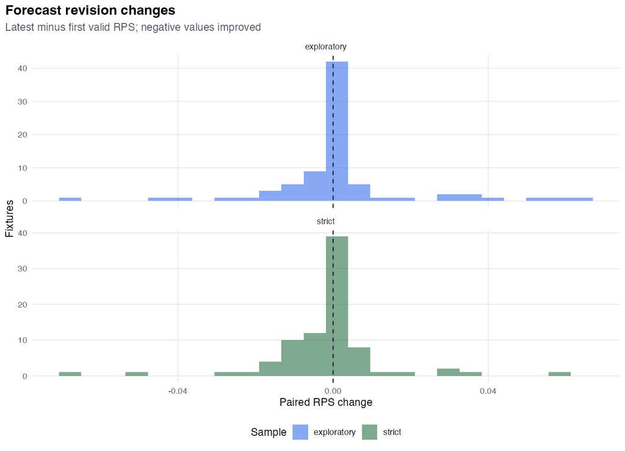

# 4 Goals

Over-2.5 and both-teams-to-score probabilities are scored from their archived market probabilities. Expected-goal errors are diagnostic. Complete joint scoreline coverage is explicitly zero rather than reconstructed from omitted cells.

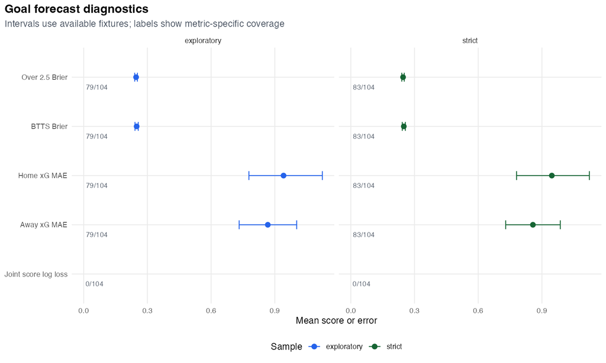

# 5 Advancement And Stage Reach

Knockout targets use the team that advanced, not the regulation-time 1X2 result. Team-stage probabilities use one deterministic snapshot per stage boundary, so frequent dashboard revisions do not inflate sample size.

Knockout advancement scores

| sample | view | brier | log_loss | n |
| --- | --- | --- | --- | --- |
| exploratory | first_valid | 0.1700 | 0.5195 | 30 |
| strict | first_valid | 0.1721 | 0.5244 | 31 |
| exploratory | latest_valid | 0.1696 | 0.5191 | 30 |
| strict | latest_valid | 0.1719 | 0.5240 | 31 |

Anchored team-stage scores

| sample | anchor_type | target_stage | brier | log_loss | n_teams |
| --- | --- | --- | --- | --- | --- |
| exploratory | pre_stage | champion | 0.0128 | 0.0337 | 48 |
| strict | pre_stage | champion | 0.0128 | 0.0337 | 48 |
| exploratory | pre_stage | final | 0.0000 | 0.0000 | 48 |
| strict | pre_stage | final | 0.0000 | 0.0000 | 48 |
| exploratory | pre_stage | quarterfinal | 0.0000 | 0.0000 | 48 |
| strict | pre_stage | quarterfinal | 0.0000 | 0.0000 | 48 |
| exploratory | pre_stage | round_of_16 | 0.0587 | 0.1939 | 48 |
| strict | pre_stage | round_of_16 | 0.0000 | 0.0000 | 48 |
| exploratory | pre_stage | round_of_32 | 0.0373 | 0.1178 | 48 |
| strict | pre_stage | round_of_32 | 0.0000 | 0.0000 | 48 |
| exploratory | pre_stage | semifinal | 0.0071 | 0.0283 | 48 |
| strict | pre_stage | semifinal | 0.0000 | 0.0000 | 48 |

# 6 Calibration

Calibration is shown one class versus the rest. Bins are deterministic quantile bins; cuts with fewer than five observations are marked sparse.

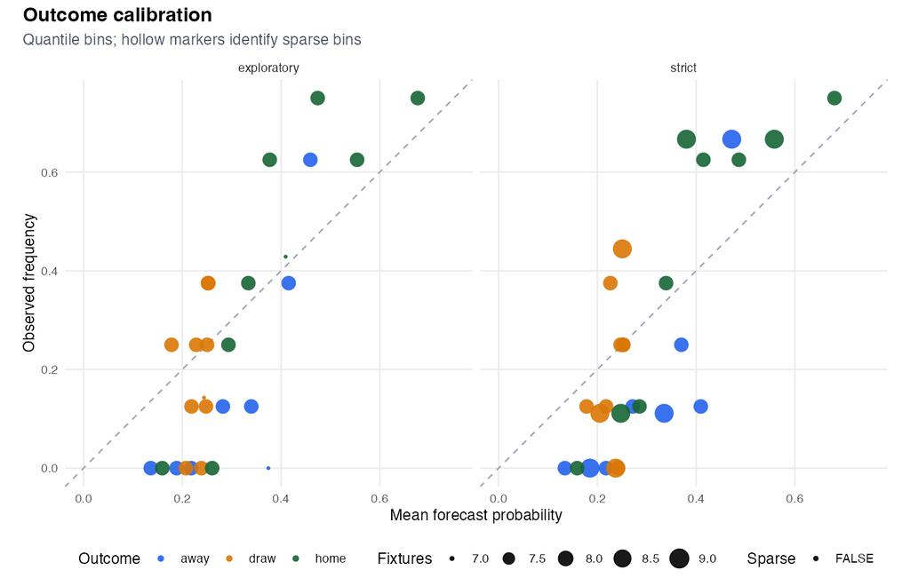

# 7 Fixture Ledger

All 104 official fixtures and forecast evidence

|  | match_id | stage | round | kickoff_utc | home_team | away_team | strict | exploratory | status | first_p_home | first_p_draw | first_p_away | first_commit_sha | first_generated_at_utc | latest_p_home | latest_p_draw | latest_p_away | latest_commit_sha | latest_generated_at_utc | primary_reason | validation_flags |
| --- | --- | --- | --- | --- | --- | --- | --- | --- | --- | --- | --- | --- | --- | --- | --- | --- | --- | --- | --- | --- | --- |
| 89 | GA01 | group | Group A | 2026-06-11T19:00Z | Mexico | South Africa | FALSE | FALSE | missing_or_rejected | NA | NA | NA | NA | NA | NA | NA | NA | NA | NA | post_kickoff_commit | post_kickoff_commit |
| 90 | GA02 | group | Group A | 2026-06-12T02:00Z | Korea Republic | Czech Republic | FALSE | FALSE | missing_or_rejected | NA | NA | NA | NA | NA | NA | NA | NA | NA | NA | post_kickoff_commit | post_kickoff_commit |
| 95 | GB01 | group | Group B | 2026-06-12T19:00Z | Canada | Bosnia and Herzegovina | FALSE | FALSE | missing_or_rejected | NA | NA | NA | NA | NA | NA | NA | NA | NA | NA | post_kickoff_commit | post_kickoff_commit |
| 94 | GD01 | group | Group D | 2026-06-13T01:00Z | United States | Paraguay | FALSE | FALSE | missing_or_rejected | NA | NA | NA | NA | NA | NA | NA | NA | NA | NA | probability_invalid | post_kickoff_commit;probability_invalid |
| 96 | GB02 | group | Group B | 2026-06-13T19:00Z | Qatar | Switzerland | FALSE | FALSE | missing_or_rejected | NA | NA | NA | NA | NA | NA | NA | NA | NA | NA | post_kickoff_commit | post_kickoff_commit |
| 84 | GC01 | group | Group C | 2026-06-13T22:00Z | Brazil | Morocco | FALSE | FALSE | missing_or_rejected | NA | NA | NA | NA | NA | NA | NA | NA | NA | NA | probability_invalid | post_kickoff_commit;probability_invalid |
| 98 | GC02 | group | Group C | 2026-06-14T01:00Z | Haiti | Scotland | FALSE | FALSE | missing_or_rejected | NA | NA | NA | NA | NA | NA | NA | NA | NA | NA | post_kickoff_commit | post_kickoff_commit |
| 100 | GD02 | group | Group D | 2026-06-14T04:00Z | Australia | Turkey | FALSE | FALSE | missing_or_rejected | NA | NA | NA | NA | NA | NA | NA | NA | NA | NA | post_kickoff_commit | post_kickoff_commit |
| 101 | GE02 | group | Group E | 2026-06-14T17:00Z | Germany | Curaçao | FALSE | FALSE | missing_or_rejected | NA | NA | NA | NA | NA | NA | NA | NA | NA | NA | post_kickoff_commit | post_kickoff_commit |
| 93 | GF01 | group | Group F | 2026-06-14T20:00Z | Netherlands | Japan | FALSE | FALSE | missing_or_rejected | NA | NA | NA | NA | NA | NA | NA | NA | NA | NA | probability_invalid | post_kickoff_commit;probability_invalid |
| 87 | GE01 | group | Group E | 2026-06-14T23:00Z | Ivory Coast | Ecuador | FALSE | FALSE | missing_or_rejected | NA | NA | NA | NA | NA | NA | NA | NA | NA | NA | post_kickoff_generation | post_kickoff_generation;post_kickoff_commit |
| 99 | GF02 | group | Group F | 2026-06-15T02:00Z | Sweden | Tunisia | FALSE | FALSE | missing_or_rejected | NA | NA | NA | NA | NA | NA | NA | NA | NA | NA | post_kickoff_generation | post_kickoff_generation;post_kickoff_commit |
| 102 | GH02 | group | Group H | 2026-06-15T16:00Z | Spain | Cape Verde | FALSE | FALSE | missing_or_rejected | NA | NA | NA | NA | NA | NA | NA | NA | NA | NA | post_kickoff_commit | post_kickoff_commit |
| 97 | GG02 | group | Group G | 2026-06-15T19:00Z | Belgium | Egypt | FALSE | FALSE | missing_or_rejected | NA | NA | NA | NA | NA | NA | NA | NA | NA | NA | probability_invalid | post_kickoff_generation;post_kickoff_commit;probability_invalid |
| 92 | GH01 | group | Group H | 2026-06-15T22:00Z | Saudi Arabia | Uruguay | FALSE | FALSE | missing_or_rejected | NA | NA | NA | NA | NA | NA | NA | NA | NA | NA | post_kickoff_generation | post_kickoff_generation;post_kickoff_commit |
| 86 | GG01 | group | Group G | 2026-06-16T01:00Z | Iran | New Zealand | FALSE | FALSE | missing_or_rejected | NA | NA | NA | NA | NA | NA | NA | NA | NA | NA | post_kickoff_generation | post_kickoff_generation;post_kickoff_commit |
| 85 | GI01 | group | Group I | 2026-06-16T19:00Z | France | Senegal | FALSE | FALSE | missing_or_rejected | NA | NA | NA | NA | NA | NA | NA | NA | NA | NA | post_kickoff_commit | post_kickoff_commit |
| 103 | GI02 | group | Group I | 2026-06-16T22:00Z | Iraq | Norway | FALSE | FALSE | missing_or_rejected | NA | NA | NA | NA | NA | NA | NA | NA | NA | NA | probability_invalid | post_kickoff_generation;post_kickoff_commit;probability_invalid |
| 91 | GJ01 | group | Group J | 2026-06-17T01:00Z | Argentina | Algeria | FALSE | FALSE | missing_or_rejected | NA | NA | NA | NA | NA | NA | NA | NA | NA | NA | post_kickoff_generation | post_kickoff_generation;post_kickoff_commit |
| 88 | GJ02 | group | Group J | 2026-06-17T04:00Z | Austria | Jordan | FALSE | FALSE | missing_or_rejected | NA | NA | NA | NA | NA | NA | NA | NA | NA | NA | probability_invalid | post_kickoff_commit;probability_invalid |
| 41 | GK01 | group | Group K | 2026-06-17T17:00Z | Portugal | DR Congo | TRUE | FALSE | verified | 0.5920 | 0.2173 | 0.1907 | 741204959608e80084183178faeb490ddbc8c5cc | 2026-06-17T07:39:04Z | 0.5920 | 0.2173 | 0.1907 | 7df6420c50e34be131403b4c49da91c707505f07 | 2026-06-17T15:59:57Z | post_kickoff_generation | post_kickoff_generation;post_kickoff_commit |
| 48 | GL02 | group | Group L | 2026-06-17T20:00Z | England | Croatia | TRUE | FALSE | verified | 0.5170 | 0.2366 | 0.2464 | 741204959608e80084183178faeb490ddbc8c5cc | 2026-06-17T07:39:04Z | 0.5170 | 0.2366 | 0.2464 | 53446812fad0b4a933b7cc17fd06fdf372fbdd1f | 2026-06-17T19:09:37Z | post_kickoff_generation | post_kickoff_generation;post_kickoff_commit |
| 47 | GL01 | group | Group L | 2026-06-17T23:00Z | Ghana | Panama | TRUE | FALSE | verified | 0.3643 | 0.2527 | 0.3830 | 741204959608e80084183178faeb490ddbc8c5cc | 2026-06-17T07:39:04Z | 0.3643 | 0.2527 | 0.3830 | fe4c1a682f98b779b02f52746930f4ba6354304d | 2026-06-17T22:03:16Z | post_kickoff_generation | post_kickoff_generation;post_kickoff_commit;source_cutoff_not_proven |
| 42 | GK02 | group | Group K | 2026-06-18T02:00Z | Uzbekistan | Colombia | TRUE | TRUE | verified | 0.2665 | 0.2422 | 0.4913 | 741204959608e80084183178faeb490ddbc8c5cc | 2026-06-17T07:39:04Z | 0.2638 | 0.2409 | 0.4953 | 6d363deb5cad8984fb398b490b628de458b1662a | 2026-06-18T00:39:09Z | post_kickoff_commit | post_kickoff_commit |
| 1 | GA03 | group | Group A | 2026-06-18T16:00Z | Czech Republic | South Africa | TRUE | TRUE | verified | 0.4106 | 0.2516 | 0.3379 | 2be8fd292dda3918b17851e1d95560495209e053 | 2026-06-17T08:47:40Z | 0.4106 | 0.2516 | 0.3379 | 1f5eb3c176382f05690ba82379b31a1a0b1c1c87 | 2026-06-18T14:04:00Z | probability_invalid | probability_invalid |
| 5 | GB03 | group | Group B | 2026-06-18T19:00Z | Switzerland | Bosnia and Herzegovina | TRUE | TRUE | verified | 0.5848 | 0.2195 | 0.1958 | 2be8fd292dda3918b17851e1d95560495209e053 | 2026-06-17T08:47:40Z | 0.5846 | 0.2195 | 0.1958 | 1f5eb3c176382f05690ba82379b31a1a0b1c1c87 | 2026-06-18T14:04:00Z | probability_invalid | probability_invalid |
| 6 | GB04 | group | Group B | 2026-06-18T22:00Z | Canada | Qatar | TRUE | TRUE | verified | 0.5963 | 0.2158 | 0.1879 | 741204959608e80084183178faeb490ddbc8c5cc | 2026-06-17T07:39:04Z | 0.5962 | 0.2158 | 0.1880 | 1f5eb3c176382f05690ba82379b31a1a0b1c1c87 | 2026-06-18T14:04:00Z | post_kickoff_commit | post_kickoff_commit |
| 2 | GA04 | group | Group A | 2026-06-19T01:00Z | Mexico | Korea Republic | TRUE | TRUE | verified | 0.4081 | 0.2517 | 0.3402 | 741204959608e80084183178faeb490ddbc8c5cc | 2026-06-17T07:39:04Z | 0.4082 | 0.2517 | 0.3401 | 1f5eb3c176382f05690ba82379b31a1a0b1c1c87 | 2026-06-18T14:04:00Z | post_kickoff_commit | post_kickoff_commit |
| 14 | GD04 | group | Group D | 2026-06-19T19:00Z | United States | Australia | TRUE | TRUE | verified | 0.3426 | 0.2520 | 0.4054 | 741204959608e80084183178faeb490ddbc8c5cc | 2026-06-17T07:39:04Z | 0.3428 | 0.2520 | 0.4052 | 77c72265674dde104627a926e7533cf4b8c625f9 | 2026-06-19T18:16:29Z | post_kickoff_generation | post_kickoff_generation;post_kickoff_commit |
| 9 | GC03 | group | Group C | 2026-06-19T22:00Z | Scotland | Morocco | TRUE | TRUE | verified | 0.1834 | 0.2152 | 0.6014 | 741204959608e80084183178faeb490ddbc8c5cc | 2026-06-17T07:39:04Z | 0.1824 | 0.2147 | 0.6029 | 12c36e6536fee8ba6b15d2ac4a9f695d54cfaa9a | 2026-06-19T20:48:55Z | post_kickoff_generation | post_kickoff_generation;post_kickoff_commit |

[output cut: 74 more lines]

# 8 Appendices

## 8.1 Stage Cuts

Stage-specific metric cuts

|  | sample | view | target | metric | cut_type | cut_value | n_scored | n_official | coverage | estimate | lower | upper |
| --- | --- | --- | --- | --- | --- | --- | --- | --- | --- | --- | --- | --- |
| 8 | exploratory | first_valid | btts | btts_brier | stage | group | 49 | 52 | 0.9423 | 0.2446 | 0.2341 | 0.2548 |
| 9 | exploratory | first_valid | btts | btts_brier | stage | knockout | 30 | 31 | 0.9677 | 0.2558 | 0.2443 | 0.2673 |
| 17 | exploratory | first_valid | btts | btts_log_loss | stage | group | 49 | 52 | 0.9423 | 0.6824 | 0.6629 | 0.7015 |
| 18 | exploratory | first_valid | btts | btts_log_loss | stage | knockout | 30 | 31 | 0.9677 | 0.7049 | 0.6811 | 0.7289 |
| 26 | exploratory | first_valid | goals | away_xg_absolute_error | stage | group | 49 | 52 | 0.9423 | 0.8894 | 0.7099 | 1.0780 |
| 27 | exploratory | first_valid | goals | away_xg_absolute_error | stage | knockout | 30 | 31 | 0.9677 | 0.8201 | 0.6302 | 1.0141 |
| 35 | exploratory | first_valid | goals | home_xg_absolute_error | stage | group | 49 | 52 | 0.9423 | 1.1058 | 0.8633 | 1.3766 |
| 36 | exploratory | first_valid | goals | home_xg_absolute_error | stage | knockout | 30 | 31 | 0.9677 | 0.6466 | 0.5069 | 0.7925 |
| 44 | exploratory | first_valid | goals | total_xg_squared_error | stage | group | 49 | 52 | 0.9423 | 3.4309 | 2.5245 | 4.4493 |
| 45 | exploratory | first_valid | goals | total_xg_squared_error | stage | knockout | 30 | 31 | 0.9677 | 1.7106 | 1.0077 | 2.4290 |
| 53 | exploratory | first_valid | over_2_5 | over_2_5_brier | stage | group | 49 | 52 | 0.9423 | 0.2479 | 0.2395 | 0.2562 |
| 54 | exploratory | first_valid | over_2_5 | over_2_5_brier | stage | knockout | 30 | 31 | 0.9677 | 0.2440 | 0.2343 | 0.2524 |
| 62 | exploratory | first_valid | over_2_5 | over_2_5_log_loss | stage | group | 49 | 52 | 0.9423 | 0.6890 | 0.6719 | 0.7045 |
| 63 | exploratory | first_valid | over_2_5 | over_2_5_log_loss | stage | knockout | 30 | 31 | 0.9677 | 0.6810 | 0.6627 | 0.6985 |
| 71 | exploratory | first_valid | regulation_1x2 | accuracy | stage | group | 49 | 52 | 0.9423 | 0.6327 | 0.4898 | 0.7551 |
| 72 | exploratory | first_valid | regulation_1x2 | accuracy | stage | knockout | 30 | 31 | 0.9677 | 0.7667 | 0.6000 | 0.9000 |
| 80 | exploratory | first_valid | regulation_1x2 | brier | stage | group | 49 | 52 | 0.9423 | 0.4971 | 0.4186 | 0.5821 |
| 81 | exploratory | first_valid | regulation_1x2 | brier | stage | knockout | 30 | 31 | 0.9677 | 0.4645 | 0.3881 | 0.5484 |
| 89 | exploratory | first_valid | regulation_1x2 | log_loss | stage | group | 49 | 52 | 0.9423 | 0.8611 | 0.7519 | 0.9811 |
| 90 | exploratory | first_valid | regulation_1x2 | log_loss | stage | knockout | 30 | 31 | 0.9677 | 0.8163 | 0.7039 | 0.9355 |
| 98 | exploratory | first_valid | regulation_1x2 | rps | stage | group | 49 | 52 | 0.9423 | 0.1627 | 0.1394 | 0.1885 |
| 99 | exploratory | first_valid | regulation_1x2 | rps | stage | knockout | 30 | 31 | 0.9677 | 0.1706 | 0.1453 | 0.2014 |
| 107 | exploratory | first_valid | scoreline | away_goal_rps | stage | group | 0 | 52 | 0.0000 | NA | NA | NA |
| 108 | exploratory | first_valid | scoreline | away_goal_rps | stage | knockout | 0 | 31 | 0.0000 | NA | NA | NA |
| 116 | exploratory | first_valid | scoreline | exact_score_hit | stage | group | 0 | 52 | 0.0000 | NA | NA | NA |
| 117 | exploratory | first_valid | scoreline | exact_score_hit | stage | knockout | 0 | 31 | 0.0000 | NA | NA | NA |
| 125 | exploratory | first_valid | scoreline | home_goal_rps | stage | group | 0 | 52 | 0.0000 | NA | NA | NA |
| 126 | exploratory | first_valid | scoreline | home_goal_rps | stage | knockout | 0 | 31 | 0.0000 | NA | NA | NA |
| 134 | exploratory | first_valid | scoreline | joint_scoreline_log_loss | stage | group | 0 | 52 | 0.0000 | NA | NA | NA |
| 135 | exploratory | first_valid | scoreline | joint_scoreline_log_loss | stage | knockout | 0 | 31 | 0.0000 | NA | NA | NA |

[output cut: 90 more lines]

## 8.2 Outcome, Confidence, And Team-Balanced Cuts

Diagnostic aggregate cuts

|  | sample | view | target | metric | cut_type | cut_value | n_scored | n_official | coverage | estimate | lower | upper |
| --- | --- | --- | --- | --- | --- | --- | --- | --- | --- | --- | --- | --- |
| 1 | exploratory | first_valid | btts | btts_brier | confidence | high | 17 | 104 | 0.1635 | 0.2386 | 0.2118 | 0.2662 |
| 2 | exploratory | first_valid | btts | btts_brier | confidence | low | 24 | 104 | 0.2308 | 0.2532 | 0.2463 | 0.2598 |
| 3 | exploratory | first_valid | btts | btts_brier | confidence | medium | 38 | 104 | 0.3654 | 0.2507 | 0.2416 | 0.2601 |
| 4 | exploratory | first_valid | btts | btts_brier | outcome_class | away | 26 | 104 | 0.2500 | 0.2484 | 0.2343 | 0.2622 |
| 5 | exploratory | first_valid | btts | btts_brier | outcome_class | draw | 15 | 104 | 0.1442 | 0.2481 | 0.2332 | 0.2618 |
| 6 | exploratory | first_valid | btts | btts_brier | outcome_class | home | 38 | 104 | 0.3654 | 0.2496 | 0.2387 | 0.2608 |
| 10 | exploratory | first_valid | btts | btts_log_loss | confidence | high | 17 | 104 | 0.1635 | 0.6704 | 0.6181 | 0.7238 |
| 11 | exploratory | first_valid | btts | btts_log_loss | confidence | low | 24 | 104 | 0.2308 | 0.6996 | 0.6864 | 0.7133 |
| 12 | exploratory | first_valid | btts | btts_log_loss | confidence | medium | 38 | 104 | 0.3654 | 0.6946 | 0.6756 | 0.7131 |
| 13 | exploratory | first_valid | btts | btts_log_loss | outcome_class | away | 26 | 104 | 0.2500 | 0.6899 | 0.6621 | 0.7171 |
| 14 | exploratory | first_valid | btts | btts_log_loss | outcome_class | draw | 15 | 104 | 0.1442 | 0.6893 | 0.6590 | 0.7170 |
| 15 | exploratory | first_valid | btts | btts_log_loss | outcome_class | home | 38 | 104 | 0.3654 | 0.6923 | 0.6683 | 0.7157 |
| 19 | exploratory | first_valid | goals | away_xg_absolute_error | confidence | high | 17 | 104 | 0.1635 | 0.7408 | 0.5587 | 0.9142 |
| 20 | exploratory | first_valid | goals | away_xg_absolute_error | confidence | low | 24 | 104 | 0.2308 | 0.8376 | 0.6399 | 1.0369 |
| 21 | exploratory | first_valid | goals | away_xg_absolute_error | confidence | medium | 38 | 104 | 0.3654 | 0.9339 | 0.7154 | 1.1831 |
| 22 | exploratory | first_valid | goals | away_xg_absolute_error | outcome_class | away | 26 | 104 | 0.2500 | 1.0324 | 0.7620 | 1.3286 |
| 23 | exploratory | first_valid | goals | away_xg_absolute_error | outcome_class | draw | 15 | 104 | 0.1442 | 0.8469 | 0.5612 | 1.1339 |
| 24 | exploratory | first_valid | goals | away_xg_absolute_error | outcome_class | home | 38 | 104 | 0.3654 | 0.7536 | 0.6065 | 0.8971 |
| 28 | exploratory | first_valid | goals | home_xg_absolute_error | confidence | high | 17 | 104 | 0.1635 | 1.0115 | 0.7490 | 1.3058 |
| 29 | exploratory | first_valid | goals | home_xg_absolute_error | confidence | low | 24 | 104 | 0.2308 | 0.8845 | 0.6607 | 1.0988 |
| 30 | exploratory | first_valid | goals | home_xg_absolute_error | confidence | medium | 38 | 104 | 0.3654 | 0.9252 | 0.6332 | 1.2453 |
| 31 | exploratory | first_valid | goals | home_xg_absolute_error | outcome_class | away | 26 | 104 | 0.2500 | 0.6141 | 0.4415 | 0.7872 |
| 32 | exploratory | first_valid | goals | home_xg_absolute_error | outcome_class | draw | 15 | 104 | 0.1442 | 1.0550 | 0.7333 | 1.3839 |
| 33 | exploratory | first_valid | goals | home_xg_absolute_error | outcome_class | home | 38 | 104 | 0.3654 | 1.0997 | 0.8122 | 1.4163 |
| 37 | exploratory | first_valid | goals | total_xg_squared_error | confidence | high | 17 | 104 | 0.1635 | 2.7509 | 1.3104 | 4.4877 |
| 38 | exploratory | first_valid | goals | total_xg_squared_error | confidence | low | 24 | 104 | 0.2308 | 2.7149 | 1.6115 | 4.0263 |
| 39 | exploratory | first_valid | goals | total_xg_squared_error | confidence | medium | 38 | 104 | 0.3654 | 2.8292 | 1.8869 | 3.8345 |
| 40 | exploratory | first_valid | goals | total_xg_squared_error | outcome_class | away | 26 | 104 | 0.2500 | 2.1919 | 1.4083 | 3.1361 |
| 41 | exploratory | first_valid | goals | total_xg_squared_error | outcome_class | draw | 15 | 104 | 0.1442 | 4.7152 | 2.7633 | 6.7965 |
| 42 | exploratory | first_valid | goals | total_xg_squared_error | outcome_class | home | 38 | 104 | 0.3654 | 2.4135 | 1.5803 | 3.3762 |

[output cut: 390 more lines]

## 8.3 Reproducibility Contract

The report reads only the immutable fixture, ledger, selection, scoring, calibration, advancement, stage-reach, and checksum artifacts in the evaluation bundle. It performs no model fitting and does not alter forecast evidence.